# kyles_solution

Alli is analysing FASTQ RNA-seq data. In order to practice programming and get a handle on the problems involved, we came up with a simple problem derived from the beginning of the RNA sequence work flow: now that I have sequenced multiple copies DNA which was synthesized from a strand of RNA, how do I determine which sequences were derived from which RNA strands?

In our slightly contrived example, there were 10 original RNA strands, each of different lengths. We replicated each one 10 times, which gives us a total of 100 sequences. The problem is, each time we replicated a sequence, there were a few errors. In this example, all the errors are single replacement mutations (an A got replaced with a G). Each copy has an unknown number of these point mutations. Our goal is to use the 100 sequences to recover the original 10 RNA strands. This isn't exactly the same problem that RNA-seq programs deal with, but many of the issues are the same.

```python
import numpy as np
RNA_filename='RNA_sequence.txt'
RNA_file=open(RNA_filename)
RNA=[]
for line in RNA_file:
    RNA.append(line.strip('\n'))
RNA_file.close()
groups=[]
print(RNA[:10])
```

```
['GTAATTCTGTGCGCCAGACGATCCTACAAGTGTTGTGTATTACACTTTTGACGATTGAGTGTTCGGTTATACTACTATGGGTTTTTC', 'GTTACTCTGTTCTACGCTTCGACGCCATCCCTCTTGGTGCGCCTGAAATTGGTGAATTAGTCGATTGAGGGGGCGATTTATTAGTCCCTAGTGCAACT', 'GTCGTCACCCGGTGCCAGGGGCGCAAACACGAGAGTTAGTGATGGCCTAGAAAGCACTCGGAGCAGTGCATGCTTGATACTGCGGATGTTCAACAGGAATG', '…
```

```python
Diff=np.zeros((len(RNA),len(RNA)))
for i in np.arange(len(RNA)):
    for j in np.arange(len(RNA)):
        min_len=np.min([len(RNA[i]),len(RNA[j])])
        for cidx in np.arange(min_len):
            if RNA[i][cidx]==RNA[j][cidx]:
                Diff[i,j]+=1
```

```python
Diff
```

```
array([[  87.,   20.,   22., ...,   18.,   16.,   24.],
       [  20.,   98.,   22., ...,   23.,   24.,   25.],
       [  22.,   22.,  101., ...,   16.,   16.,   25.],
       ...,
       [  18.,   23.,   16., ...,  111.,   35.,   23.],
       [  16.,   24.,   16., ...,   35.,  109.,   24.],
       [  24.,   25.,   25., ...,   23.,   24.,   98.]])
```

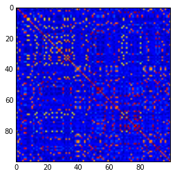

```python
import matplotlib.pyplot as plt
%matplotlib inline
import matplotlib.image as mpimg
plt.imshow(Diff)
```